# Logic and Scientific Thinking

Formal Fallacies

Bogdan G. Popescu

bgpopescu@tec.mx

Tecnologico de Monterrey

# Welcome

## Recap

| Question | Answer from the previous session |
| --- | --- |
| Validity vs. truth? | Valid logic can carry false premises |
| The three valid **conditional** shapes? | Modus ponens, modus tollens, hypothetical syllogism |
| The two traps you met? | Affirming the consequent, denying the antecedent |

# The Formal Toolkit

## Necessary vs. Sufficient Conditions

“If dog, then mammal” points **one way**:

- **Dog is sufficient** for mammal — dog guarantees mammal.
- **Mammal is necessary** for dog — no mammal, no dog.

**The Rule:**

- forward (dog → mammal)
- contrapositive (not mammal → not dog).

**Invalid:**

- reverse (mammal → dog)
- negate both (not dog → not mammal).

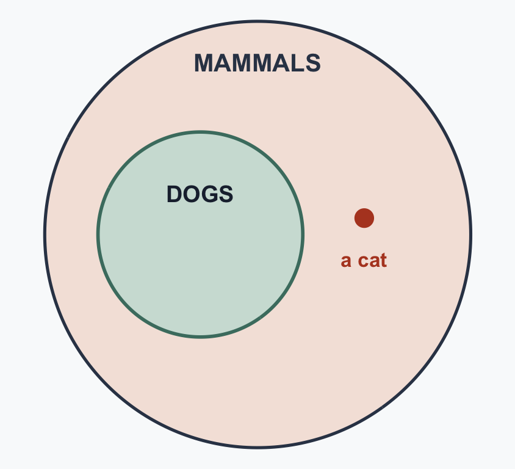

## Necessary vs. Sufficient Conditions

“If dog, then mammal” points **one way**:

- **Dog is sufficient** for mammal — dog guarantees mammal.
- **Mammal is necessary** for dog — no mammal, no dog.

**one direction only**

Rule: **P → Q, not the reverse (Q → P).**

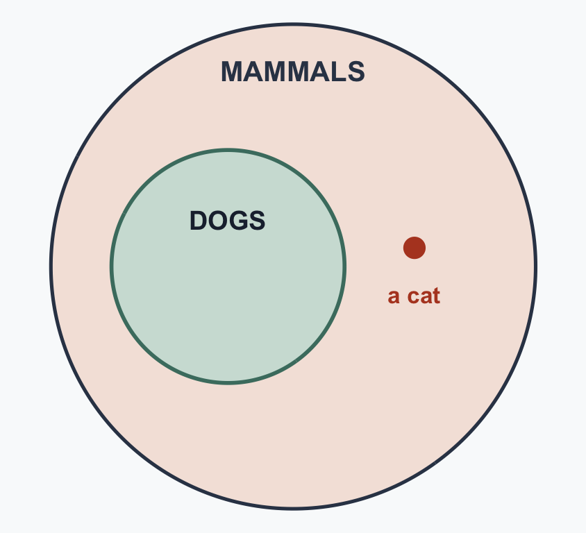

## The Traps, in Practice

- *“If the election were rigged, there’d be long lines. Lines were long — so it was rigged.”*
  - **Affirming the consequent** — long lines aren’t *sufficient* to prove rigging.
- *“If it’s spam, it has typos. This email has none — so it’s safe.”*
  - **Denying the antecedent** — typos aren’t *necessary* for spam; polished scams exist.

Necessary vs. sufficient names *why* each trap fails: it swaps **sufficient** for **necessary**.

# Exercise 1 — Tool or Trap?

Valid tool or its trap? Name each.

- If rain, then wet. It rained. So it’s wet.
- If rain, then wet. It’s wet. So it rained.
- If in Paris, then in France. Not in France. So not in Paris.
- If in Paris, then in France. Not in Paris. So not in France.

## Exercise 1 — Answers

Each pair shares **one rule**. Only the **second premise** moves.

**Pair A — rule: *If rain, then wet.***

- *It rained. So it’s wet.* → **modus ponens** · **TOOL**
- *It’s wet. So it rained.* → **affirming the consequent** · **TRAP** — a sprinkler could have wet it.

**Pair B — rule: *If in Paris, then in France.***

- *Not in France. So not in Paris.* → **modus tollens** · **TOOL**
- *Not in Paris. So not in France.* → **denying the antecedent** · **TRAP** — Lyon is not Paris, and still in France.

**One legal move, one look-alike that breaks.**

## The Toolkit at a Glance

The five conditional shapes — each valid tool beside the trap that mimics it:

| Name | Shape | Verdict |
| --- | --- | --- |
| modus ponens | If P, then Q. P. so Q | VALID |
| affirming the consequent | If P, then Q. Q. so P | INVALID |
| modus tollens | If P, then Q. Not Q. so Not P | VALID |
| denying the antecedent | If P, then Q. Not P. so Not Q | INVALID |
| hypothetical syllogism | If P, then Q. If Q, then R. so If P, then R | VALID |

Logicians catalogue many more shapes — the “or” and “all” families, and dozens beyond them. These five are the ones this course uses. After Vaughn (2019).

## So What? — Knowing the Shapes Isn’t Enough

**The recipe:**

- keep premises true
- conclusion false
- one case refutes it.

So why do the traps keep working, even on people who can check them?

A wrong move can **feel** valid — and the feeling often replaces the check.

**Act I:** that feeling at its purest.

# Act I: The Answer Comes First

## The Bat and the Ball

*No tools here — just your immediate answer.*

> A bat and a ball cost $1.10 in total.  
> The bat costs $1.00 more than the ball.  
> **How much does the ball cost?**

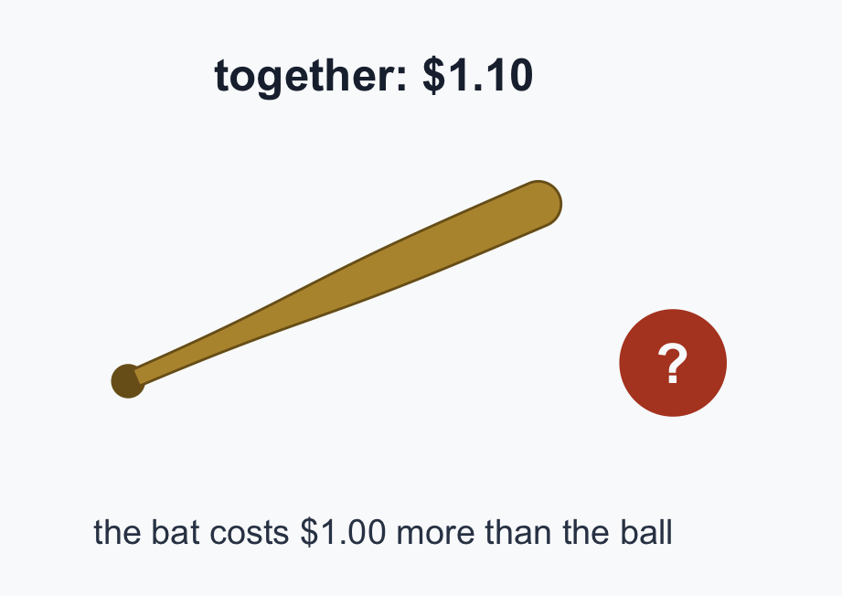

Correct answer: **5 cents.**

You’re in good company:

- many people answer **10 cents**
- the answer arrives **before** any check runs.

## Two Lines of Algebra

Call the ball $x$. Then the bat is $x + \$1.00$.

- Together they cost $1.10: $\;x + (x + 1.00) = 1.10$
- Subtract the $1.00: $\;2x = 0.10$
- Divide by 2: $\;x = 0.05$ — the ball costs **5 cents**.
- Check: ball $0.05 + bat $1.05 = **$1.10** ✓
- Most solvers split $1.10 into $1.00 + 10¢ without noticing.
- Answering an easier question than the one asked.

The same lesson as the counterexample test: **check, don’t feel.**

## So What? — Feeling Right Isn’t Being Right

A conclusion can feel right **before reasoning.**

Owning the checking tools doesn’t mean we **use** them.

## Conclusion

**A valid *form* is not a true *conclusion* — and a confident *feeling* is not a checked one.** Today: the formal half.

## References

- Vaughn, L. (2019). *The power of critical thinking: Effective reasoning about ordinary and extraordinary claims* (6th ed.). Oxford University Press.